# **Analyzing Video Game Sales to Predict Personalized Recommendations**

Spring 2024 Data Science Project

Chamarr Auber & Han Qiu

Contribution Checkpoints:

A: Project idea - 5%

B: Dataset Curation and Preprocessing - 10%

C: Data Exploration and Summary Statistics - 10%

D: ML Algorithm Design/Development - 25%

E: ML Algorithm Training and Test Data Analysis - 20%

F: Visualization, Result Analysis, Conclusion - 15%

G: Final Tutorial Report Creation - 10%

H: Additional (not listed above, if any) - 5%

Member 1: Chamarr Auber, Contribution: 50% (did not contribute to A, D, F, H).

Member 2: Han Qiu, Contribution: 50% (did not contribute to B, C, E, G).

"We, all team members, agree together that the above information is true, and we are confident about our contributions to this submitted project/final tutorial."

- Chamarr Auber, 5/6/2024
- Han Qiu, 5/6/2024

Han Qiu: I was the one who came up with the general idea of the analyzing video game sales to predict personalized recommendations. As a whole, I was usually the one coming up with the central ideas to work with and to design our code, tests, and algorithms around, and as such, I was also the one who did most of the writing introductions and descriptions. When it came to the primary analysis with our machine learning technique, me and my partner split the work. I handled the initial development stages of our cluster algorithm, setting it up with the appropriate data in mind. After that, I handled the visualization aspect of all our analysis, creating our data graph and explaining the results and insights of our research. In the end, I also did some additional reworking and rephrasing to our project structurally, and grammatically, making sure that it was in a accepted state to be submitted.

Chamarr Auber: I was the one who came up with the idea that we should use a cluster algorithm as our means of primary analysis. Given our objective, I thoroughly examined every aspect of our dataset that could prove helpful to making accurate personalized recommendations. Our dataset was massive, so I began to process and curate essential elements from it to make it more accessible to the average viewer. After that I designed the data exploration aspect of our dataset, utilizing chi squared test, z-test, and ANOVA test for our hypothesis testing based on the specifics provided by my partner. After that me and my partner split our work on the primary analysis, where I handled testing the results and training our cluster algorithm to predict the recommendations. In the end I also provided the final insights and conclusions for our project.

# **Introduction:**

Video games have been a popular and rising medium of entertainment over the past few decades. With the vast array of genres, platforms, and publishers over the years, the task of choosing which game is worth investing time and money in can be daunting. This is where our project steps in. Our objective is to examine a comprehensive dataset of video game sales up until 2016 to better predict and personalize game recommendations for individuals. This analysis aims to utilize a cluster algorithm to identify patterns and trends in video game preferences and sales that can play a factor in personalized recommendations.

As people who buy and play a lot of video games themselves, we were motivated to take up this endeavor after taking into consideration how many games have been rising in price and oversaturating the market, along with our limited amount of free time thanks to school and work. We found that it would be best if there were some means of personalized recommendations of video games that would save our wallets and make it worth while to put our precious time into.

This analysis is crucial because it supports the creation of a model that not only enhances user engagement by providing gamers with recommendations finely tuned to their tastes, but it also plays a role in helping game developers and marketers to understand their audience better. By predicting and personalizing game recommendations, we can potentially increase user satisfaction and retention rates for video games. Moreover, this project contributes to the idea of an automated recommendation systems based on algorithms and data, which are pivotal in the modern era of digital commerce and online entertainment

```python
import pandas as pd
import numpy as np
from scipy.stats import chi2_contingency
import matplotlib.pyplot as plt
from scipy import stats
from scipy.stats import f_oneway
from scipy.stats import sem
from sklearn.cluster import KMeans
from sklearn.preprocessing import OneHotEncoder
import random
from sklearn.decomposition import PCA
```

# **Data Curation**

In this section, we will be collecting and optimizing all relevant data from our video sales dataset found from https://www.kaggle.com/datasets/sidtwr/videogames-sales-dataset?select=Video_Games_Sales_as_at_22_Dec_2016.csv. This dataset contains information on video games sales as of Dec. 2016 across a vast array of different platforms, genres, publishers, year of release, and from different regions such as North America, Europe, Japan, and other.

We shall begin by collecting information from across the different regions.

```python
# Load the dataset into a pandas DataFrame
vgs_df = pd.read_csv("Video_Game_Sales.csv")

print(vgs_df.head())
```

```
                       Name Platform  Year_of_Release         Genre Publisher  \
0                Wii Sports      Wii           2006.0        Sports  Nintendo
1         Super Mario Bros.      NES           1985.0      Platform  Nintendo
2            Mario Kart Wii      Wii           2008.0        Racing  Nintendo
3         Wii Sports Resort      Wii           2009.0        Sports  Nintendo
4  Pokemon Red/Pokemon Blue       GB           1996.0  Role-Playing  Nintendo

   NA_Sales  EU_Sales  JP_Sales  Other_Sales  Global_Sales  Critic_Score  \
0     41.36     28.96      3.77         8.45         82.53          76.0
1     29.08      3.58      6.81         0.77         40.24           NaN
2     15.68     12.76      3.79         3.29         35.52          82.0
3     15.61     10.93      3.28         2.95         32.77          80.0
4     11.27      8.89     10.22         1.00         31.37           NaN

   Critic_Count  User_Score  User_Count Developer Rating
0          51.0         8.0       322.0  Nintendo      E
1           NaN         NaN         NaN       NaN    NaN
2          73.0         8.3       709.0  Nintendo      E
3          73.0         8.0       192.0  Nintendo      E
4           NaN         NaN         NaN       NaN    NaN
```

The value representing the dataset are given to us as decimal numbers, but we want them to be in the value of millions (millions of copies sold). So, we must convert the decimal numbers to millions

```python
# Define a function to format numbers in millions with commas
def format_millions_with_commas(x):
    return '{:,.0f}'.format(x * 1000000)

# Apply the formatting function to specific columns using applymap
vgs_df[['NA_Sales', 'EU_Sales', 'JP_Sales', 'Other_Sales', 'Global_Sales']] = vgs_df[['NA_Sales', 'EU_Sales', 'JP_Sales', 'Other_Sales', 'Global_Sales']].applymap(format_millions_with_commas)

# Print the first few rows of the modified DataFrame to verify the changes
print(vgs_df[['NA_Sales', 'EU_Sales', 'JP_Sales', 'Other_Sales', 'Global_Sales']].head())
```

```
     NA_Sales    EU_Sales    JP_Sales Other_Sales Global_Sales
0  41,360,000  28,960,000   3,770,000   8,450,000   82,530,000
1  29,080,000   3,580,000   6,810,000     770,000   40,240,000
2  15,680,000  12,760,000   3,790,000   3,290,000   35,520,000
3  15,610,000  10,930,000   3,280,000   2,950,000   32,770,000
4  11,270,000   8,890,000  10,220,000   1,000,000   31,370,000
```

Next, to clean up the dataset a bit more is to remove any duplicates that might be in the dataset. Next, there are some columns that are irrelevant to us in experiment/prediction so we can delete these columns from the dataset as well.

```python
# Remove duplicate rows from the DataFrame
vgs_df.drop_duplicates(inplace=True)

# Print the shape of the DataFrame to see how many rows are remaining after removing duplicates
print("Shape of DataFrame after removing duplicates:", vgs_df.shape)
```

```
Shape of DataFrame after removing duplicates: (16719, 16)
```

Next, lets make the type of the sales column integers because in the dataset they are stored as objects

```python
# List of sales columns to convert
sales_columns = ['NA_Sales', 'EU_Sales', 'JP_Sales', 'Other_Sales', 'Global_Sales']

# Convert each sales column to integer type
for column in sales_columns:
    vgs_df[column] = vgs_df[column].str.replace(',', '').astype(float).astype(int)

# Verify the data type after conversion for each sales column
for column in sales_columns:
    print(f"{column}: {vgs_df[column].dtype}")
```

```
NA_Sales: int64
EU_Sales: int64
JP_Sales: int64
Other_Sales: int64
Global_Sales: int64
```

```python
# Remove the irrelevant columns from the DataFrame
vgs_df.drop(columns=["Critic_Score", "Critic_Count", "User_Score", "User_Count"], inplace=True)

# Print the first few rows of the modified DataFrame to verify the changes
print(vgs_df.head())
```

```
                       Name Platform  Year_of_Release         Genre Publisher  \
0                Wii Sports      Wii           2006.0        Sports  Nintendo
1         Super Mario Bros.      NES           1985.0      Platform  Nintendo
2            Mario Kart Wii      Wii           2008.0        Racing  Nintendo
3         Wii Sports Resort      Wii           2009.0        Sports  Nintendo
4  Pokemon Red/Pokemon Blue       GB           1996.0  Role-Playing  Nintendo

   NA_Sales  EU_Sales  JP_Sales  Other_Sales  Global_Sales Developer Rating
0  41360000  28960000   3770000      8450000      82530000  Nintendo      E
1  29080000   3580000   6810000       770000      40240000       NaN    NaN
2  15680000  12760000   3790000      3290000      35520000  Nintendo      E
3  15610000  10930000   3280000      2950000      32770000  Nintendo      E
4  11270000   8890000  10220000      1000000      31370000       NaN    NaN
```

Lastly, we are going to unabbreviate the different platforms and ratings for the video games in order to make this dataset readable to all types of users and not only people who enjoy video games.

```python
# Define a dictionary mapping abbreviated platform names to their full names
platform_mapping = {
    'X360': 'Xbox 360',
    'GB': 'Game Boy',
    'GBA': 'Game Boy Advance',
    'NES': 'Nintendo Entertainment System',
    'PS2': 'PlayStation 2',
    'PS3': 'PlayStation 3',
    'PS4': 'PlayStation 4',
    'SNES': 'Super Nintendo Entertainment System',
    'N64': 'Nintendo 64',
    'XB': 'Xbox',
    'XOne': 'Xbox One',
    'PSP': 'PlayStation Portable',
    'GC': 'Game Cube',
    'GEN': 'Sega Genesis',
    'PSV': 'PlayStation Vita',
    'SAT': 'Sega Saturn',
    'SCD': 'Sega CD',
    'WS': 'WonderSwan',
    'NG': 'Neo Geo',
    'GG': 'Game Gear',
    'TG16': 'TurboGrafx-16'
}

rating_mapping = {
    'E': 'Everyone',
    'M': 'Mature',
    'T': 'Teen',
    'E10+': 'Everyone 10+',
    'K-A': 'Kids to Adults',
    'AO': 'Adults Only',
    'EC': 'Early Child',
    'RP': 'Rating Pending'
}

# Apply mapping to 'Rating' column
vgs_df['Rating'].replace(rating_mapping, inplace=True)

# Confirm changes
unique_ratings = vgs_df['Rating'].unique()
print("Updated unique ratings:")
for rating in unique_ratings:
    print(rating)


# Replace abbreviated platform names with their full names
vgs_df['Platform'].replace(platform_mapping, inplace=True)

# Print the unique values in the 'Platform' column to verify the changes
print("Unique values in the 'Platform' column after replacement:")
print(vgs_df['Platform'].unique())
```

```
Updated unique ratings:
Everyone
nan
Mature
Teen
Everyone 10+
Kids to Adults
Adults Only
Early Child
Rating Pending
Unique values in the 'Platform' column after replacement:
['Wii' 'Nintendo Entertainment System' 'Game Boy' 'DS' 'Xbox 360'
 'PlayStation 3' 'PlayStation 2' 'Super Nintendo Entertainment System'
 'Game Boy Advance' 'PlayStation 4' '3DS' 'Nintendo 64' 'PS' 'Xbox' 'PC'
 '2600' 'PlayStation Portable' 'Xbox One' 'WiiU' 'Game Cube'
 'Sega Genesis' 'DC' 'PlayStation Vita' 'Sega Saturn' 'Sega CD'
 'WonderSwan' 'Neo Geo' 'TurboGrafx-16' '3DO' 'Game Gear' 'PCFX']
```

# **Exploratory Data Analysis**

# **Hypothesis Testing 1**: Chi-squared test

- In this analysis, we compared the genre to the sales in each region and globally, aiming to investigate if there is an association between the genre of game and the sales in each respective region.
- Since we are examining the relationship between two categorical variables—the genre of games and their overall sales in each region—a chi-squared test is suitable in this case. In a contingency table, the chi-squared test for independence determines if these variables significantly correlate with one another.

Hypothesis: There is an association between users' preferred game genres and their regional sales preferences.

Null Hypothesis: There is no association between users' preferred game genres and their regional sales preferences.

```python
# Create contingency tables for each pair of variables
contingency_na = pd.crosstab(vgs_df['Genre'], vgs_df['NA_Sales'])
contingency_eu = pd.crosstab(vgs_df['Genre'], vgs_df['EU_Sales'])
contingency_jp = pd.crosstab(vgs_df['Genre'], vgs_df['JP_Sales'])
contingency_global = pd.crosstab(vgs_df['Genre'], vgs_df['Global_Sales'])

# Perform chi-squared tests for each contingency table
chi2_na, p_value_na, _, _ = chi2_contingency(contingency_na)
chi2_eu, p_value_eu, _, _ = chi2_contingency(contingency_eu)
chi2_jp, p_value_jp, _, _ = chi2_contingency(contingency_jp)
chi2_global, p_value_global, _, _ = chi2_contingency(contingency_global)

# Print the results of each chi-squared test
print("Chi-squared test statistic and p-value for North America sales:")
print("Chi-squared:", chi2_na)
print("P-value:", p_value_na)

print("\nChi-squared test statistic and p-value for Europe sales:")
print("Chi-squared:", chi2_eu)
print("P-value:", p_value_eu)

print("\nChi-squared test statistic and p-value for Japan sales:")
print("Chi-squared:", chi2_jp)
print("P-value:", p_value_jp)

print("\nChi-squared test statistic and p-value for global sales:")
print("Chi-squared:", chi2_global)
print("P-value:", p_value_global)
```

```
Chi-squared test statistic and p-value for North America sales:
Chi-squared: 6200.527566139783
P-value: 8.001804605145692e-65

Chi-squared test statistic and p-value for Europe sales:
Chi-squared: 4540.558283202579
P-value: 1.4859477401845338e-38

Chi-squared test statistic and p-value for Japan sales:
Chi-squared: 5339.491060732703
P-value: 4.33101490563022e-180

Chi-squared test statistic and p-value for global sales:
Chi-squared: 7804.014511827629
P-value: 1.2225791420965097e-13
```

# **Conclusion 1:**

**North America Sales:**

- P-value: 8.00 x 10^-65
- Conclusion: Since the p-value is much smaller than our significance level of 0.05, we reject the null hypothesis. This meas that there is a statistically significant evidence determining the association between users preferred game genres and their sales preferences in North America.

**Europe Sales:**

- P-value: 1.49 x 10^-38
- Conclusion: Similar to North America, the p-value is much smaller than the our significance level of 0.05. Therefore, we reject the null hypothesis. There is statistically significant association between users preferred game genres and their sales preferences in Europe.

**Japan Sales:**

- P-value: 4.33 x 10^-180
- Conclusion: The same rule applies for Japan. The p-value is smaller the the significance level of 0.05 which means that we reject the null hypothesis meaning there is statisically significant evidence portraying the association between users preferred game genres and their sales preferences in Japan.

**Global Sales:**

- P-value: 1.22 x 10^-13
- Conclusion: The p-value is smaller than our significance level 0.05. Therefore, we reject the null hypothesis meaning there is a statistically significant association between users preferred game genres and their sales preferences on a global scale.

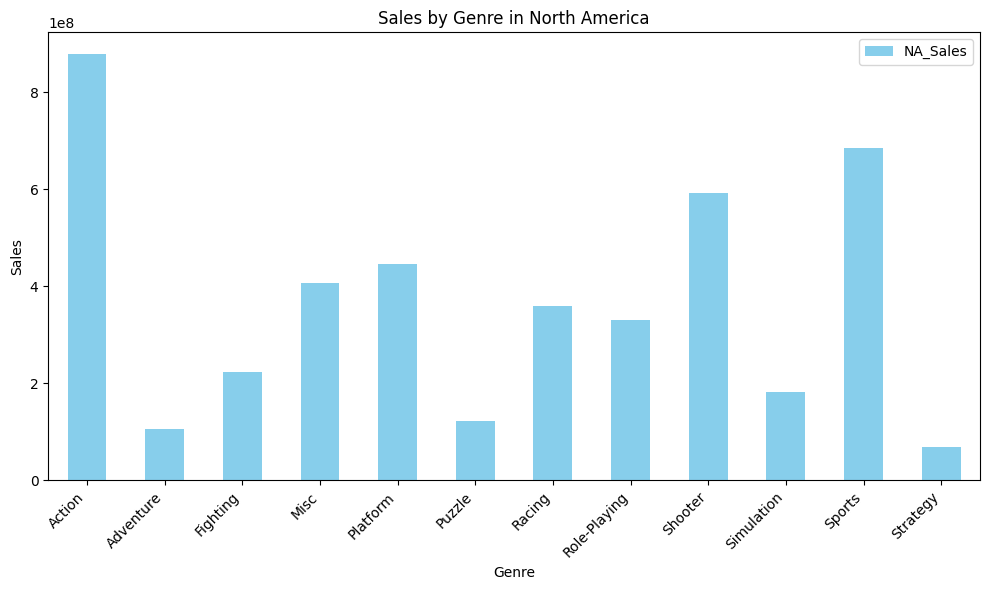

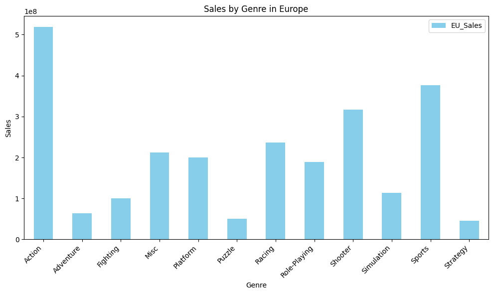

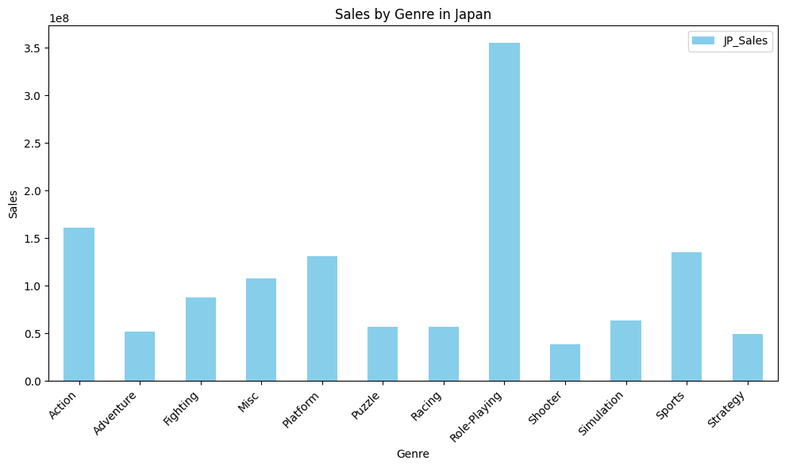

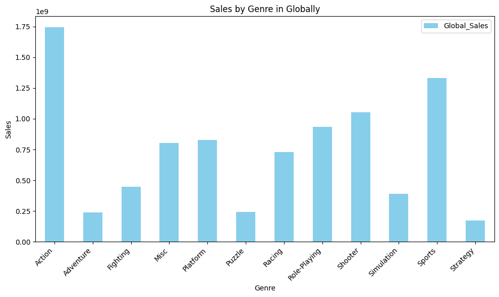

```python
region_names = {
    'NA_Sales': 'North America',
    'EU_Sales': 'Europe',
    'JP_Sales': 'Japan',
    'Global_Sales': 'Globally'
}

# Plot sales for each genre in each region
for region, full_region_name in region_names.items():

    sales_by_genre = vgs_df.groupby('Genre')[region].sum()

    # Plot the graph for the current region
    plt.figure(figsize=(10, 6))
    sales_by_genre.plot(kind='bar', color='skyblue')
    plt.title(f'Sales by Genre in {full_region_name}')
    plt.xlabel('Genre')
    plt.ylabel('Sales')
    plt.xticks(rotation=45, ha='right')
    plt.legend()
    plt.tight_layout()
    plt.show()
```

# **Hypothesis Testing 2**: Z-Test

The general question about developing a recommendation system based on user preferences and sales data is greatly helped by using the z-test to compare the mean total global sales between platforms, such as the PlayStation 2 (PS2) and other popular platforms. This statistical method makes it possible to compare sales performance between various platforms, giving important information about which platforms are more well-liked or profitable in the marketplace. The relative performance of each platform can be determined by applying the z-test to sales data analysis. This information is essential for customizing the recommendation system to users preferred platforms. The z-test also aids in determining whether observed variations in sales performance between platforms are statistically significant, which helps in determining which platforms should be given priority in the recommendation system. Overall, the z-test serves as a complex analytical tool for evaluating platform preferences and informing the design of an effective recommendation system that aligns with user's preferences and sales data.

Hypothesis: The average total game sales of game for the PlayStation 2 are different from the average total game sales for the top 5 platforms compared to the PlayStation 2

Null Hypothesis: There is no significant difference in the average total global sales of games for the PlayStation 2 compared to the top 5 platforms compared to the PlayStation 2

```python
platform_sales = {}
for platform in vgs_df['Platform'].unique():
    platform_sales[platform] = vgs_df[vgs_df['Platform'] == platform]['Global_Sales']

# Get the top 5 platforms
top_platforms = vgs_df['Platform'].value_counts().nlargest(6)[1:].index.tolist()
reference_platform = 'PlayStation 2'

#Perform Z-test for top 5 platforms compared to PS2
def z_test(sample1, sample2):
    n1, n2 = len(sample1), len(sample2)
    mean1, mean2 = sample1.mean(), sample2.mean()
    var1, var2 = sample1.var(), sample2.var()

    pooled_var = ((n1 - 1) * var1 + (n2 - 1) * var2) / (n1 + n2 - 2)
    z_score = (mean1 - mean2) / (pooled_var * ((1/n1) + (1/n2)))**0.5

    p_value = stats.norm.sf(abs(z_score)) * 2  # two-tailed test

    return z_score, p_value

# Compare the top 5 platforms to PS2
for platform in top_platforms:
    if platform == reference_platform:
        continue

    ps2_sales = platform_sales[reference_platform]
    platform_sales_comp = platform_sales[platform]
    z_score, p_value = z_test(ps2_sales, platform_sales_comp)
    print(f"Z-test for {platform} compared to {reference_platform}:")
    print(f"Z-score: {z_score}")
    print(f"P-value: {p_value}\n")
```

```
Z-test for DS compared to PlayStation 2:
Z-score: 5.2442253049534155
P-value: 1.5694032949174027e-07

Z-test for PlayStation 3 compared to PlayStation 2:
Z-score: -2.8858651989859787
P-value: 0.0039033930448791852

Z-test for Wii compared to PlayStation 2:
Z-score: -1.4414249719565195
P-value: 0.1494646595820834

Z-test for Xbox 360 compared to PlayStation 2:
Z-score: -3.9963083525750305
P-value: 6.433792094917047e-05

Z-test for PlayStation Portable compared to PlayStation 2:
Z-score: 9.760603555910034
P-value: 1.6616335323570515e-22
```

# **Conclusion 2:**

Based on the results of the Z-tests comparing the average global sales of each platform to PlayStation 2, we can make the following conclusions:

**Wii:**

- P-value: 0.149
- Conclusion: The average global sales of Wii games are not significantly different from those of PlayStation 2 games.

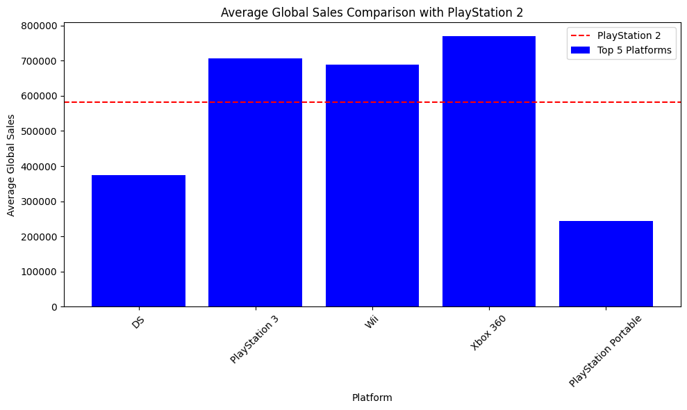

```python
# Average global sales for PlayStation 2
ps2_sales = platform_sales[reference_platform].mean()

# Average global sales for the top 5 platforms
top_platforms_sales = [platform_sales[platform].mean() for platform in top_platforms]

# Plotting
plt.figure(figsize=(10, 6))
plt.bar(top_platforms, top_platforms_sales, color='blue', label='Top 5 Platforms')
plt.axhline(y=ps2_sales, color='red', linestyle='--', label='PlayStation 2')
plt.xlabel('Platform')
plt.ylabel('Average Global Sales')
plt.title('Average Global Sales Comparison with PlayStation 2')
plt.legend()
plt.xticks(rotation=45)
plt.tight_layout()
plt.show()
```

# **Hypothesis Testing 3**: ANOVA Test

A solid method for addressing the main issue of building a recommendation system based on user preferences and sales data is provided by the suggested ANOVA test. This analysis offers good insights into how various age demographics affect sales performance by analyzing the relationship between age rating categories and average total global sales of games. The validity of conclusions is ensured by the ANOVA test, which employs statistical rigor to ascertain whether observed differences in sales across age rating categories are statistically significant. Sales data about user age preferences can be used to customize the recommendation system so that games that appeal to particular age groups are recommended, increasing user satisfaction and engagement. As a result, the ANOVA test is a useful tool for creating recommendation systems that successfully incorporate user preferences and sales data, optimizing the gaming experience for diverse demographics.

Hypothesis: There is significant difference in the average global sales of games across different rating categories.

Null Hypothesis: There is no significant difference in the average global sales of games across different rating categories.

```python
#Drop NaN values in 'Rating' and 'Global_Sales' columns
vgs_df.dropna(subset=['Rating', 'Global_Sales'], inplace=True)

rating_sales = {}
for rating in vgs_df['Rating'].unique():
    sales = vgs_df[vgs_df['Rating'] == rating]['Global_Sales']
    if len(sales) >= 2:
        rating_sales[rating] = sales

#Perform ANOVA test for multiple samples
f_statistic, p_value = f_oneway(*rating_sales.values())

print("F-statistic:", f_statistic)
print("P-value:", p_value)
```

```
F-statistic: 14.700126996449237
P-value: 8.551358958846202e-17
```

# **Conclusion 3:**

Strong evidence is found in the investigation about the correlation between video game sales worldwide and age rating categories. The computed F-statistic of 14.70 indicates a significant difference in the mean global sales average across different age rating groups. This statistic highlights the significant differences in sales performance between different age groups by evaluating the ratio of variance found between groups to that within groups. Moreover, the remarkably low p-value of roughly 8.55e-17 emphasizes how solid these results are.

This likelihood provides strong evidence against the idea that these disparities happened at random by showing how unlikely it is to observe such large variances in global sales among age rating groups if the null hypothesis were true. Age rating has a substantial impact on video game sales, as the data clearly indicates that the observed disparities in global sales across various age rating groups are statistically significant and unlikely to be the result of chance.

[figure not shown]

```python
# Calculate standard error of the mean for each rating
sem_ratings = [sem(sales) for sales in rating_sales.values()]

# Create a bar plot with error bars representing confidence intervals
plt.figure(figsize=(10, 6))
bars = plt.bar(rating_sales.keys(), [sales.mean() for sales in rating_sales.values()], color='skyblue', yerr=sem_ratings, capsize=5)
plt.xlabel('Game Rating')
plt.ylabel('Average Global Sales')
plt.title('Average Global Sales Across Age Rating Categories')
plt.xticks(rotation=45)
plt.grid(axis='y', linestyle='--', alpha=0.7)
plt.legend([bars[0]], ['95% Confidence Interval'], loc='upper right')
plt.show()
```

# **Primary Analysis**

Now that we have collected, cleaned, and explored our data, it's time to apply machine learning to the idea of predicting personalized game recommendations. The concept of machine learning is an algorithms that becomes better at performing tasks by being given data, effectively 'learning' through experience, and so, we will use a cluster algorithm to perform this analysis and predict these recommendations by giving us a varied clustered of options at the end.

```python
# Select relevant features for clustering
features = ['Genre', 'Platform', 'Publisher']

X = vgs_df[features]

# Perform one-hot encoding
encoder = OneHotEncoder()
X_encoded = encoder.fit_transform(X)

# Apply K-means clustering
kmeans = KMeans(n_clusters=5, random_state=42)
kmeans.fit(X_encoded)

cluster_labels = kmeans.labels_

# Assign cluster labels to the DataFrame
vgs_df['Cluster'] = cluster_labels

recommendations = []
for cluster in range(5):
    # Find games belonging to the cluster
    cluster_games = vgs_df[vgs_df['Cluster'] == cluster]
    if len(cluster_games) > 0:
        cluster_recommendations = cluster_games.sample(n=5, random_state=42)
        recommendations.append(cluster_recommendations)
    else:
        print(f"No games found in Cluster {cluster+1}")

# Display recommendations
for idx, cluster_recommendations in enumerate(recommendations):
    print(f"Cluster {idx+1} Recommendations:")
    print(cluster_recommendations[['Name', 'Genre', 'Platform', 'Publisher']])
    print()
```

```
Cluster 1 Recommendations:
                                     Name       Genre              Platform  \
710         Onimusha 2: Samurai's Destiny   Adventure         PlayStation 2
11466                   Petz: Dogz Family  Simulation  PlayStation Portable
10010           Merv Griffin's Crosswords      Puzzle                   Wii
8000   Battle of Giants: Dinosaurs Strike    Strategy                   Wii
5815           Dragon Ball Z: Battle of Z    Fighting         PlayStation 3

                Publisher
710                Capcom
11466             Ubisoft
10010                 THQ
8000              Ubisoft
5815   Namco Bandai Games

Cluster 2 Recommendations:
                                                    Name   Genre  \
3529   SpongeBob SquarePants featuring Nicktoons: Glo...  Action
8304                      Hunter: The Reckoning Redeemer  Action
15662                                 The Crew: Wild Run  Action
10064                     Prince of Persia: Rival Swords  Action
7213                                     All Star Karate  Action

                   Platform  Publisher
3529                     DS        THQ
8304                   Xbox  Interplay
15662                    PC    Ubisoft
10064  PlayStation Portable    Ubisoft
7213                    Wii        THQ

Cluster 3 Recommendations:
                              Name    Genre       Platform  \
6862                   Singularity  Shooter  PlayStation 3
5429  Delta Force: Black Hawk Down  Shooter           Xbox
5181                          NARC  Shooter  PlayStation 2
209       Link's Crossbow Training  Shooter            Wii
8627       BioShock The Collection  Shooter       Xbox One

                 Publisher
6862               Unknown
```

[output cut: 12 more lines]

```

                   Platform         Publisher
14955      Game Boy Advance               THQ
5857                     PS           Unknown
6899   PlayStation Portable           Ubisoft
14605                   Wii  Storm City Games
7668          PlayStation 2        Infogrames

Cluster 5 Recommendations:
                             Name   Genre       Platform    Publisher
4926   Cabela's Dangerous Hunts 2  Sports  PlayStation 2   Activision
10329             Tournament Pool  Sports            Wii    Destineer
3305    Major League Baseball 2K9  Sports       Xbox 360        Spike
4968       ESPN College Hoops 2K5  Sports           Xbox         Sega
8435                   NASCAR '15  Sports       Xbox 360  Deep Silver
```

# **Visualization**

After training our model in the previous section with the cluster algorithm, we will now utilize a PCA Cluster Graph to display our analysis.

Principal Component 1 (PC1): This axis shows which direction in the initial feature space there is the most variation in the data. Of all the linear combinations of the original attributes that are feasible, it captures the most variance in the data.

Principal Component 2 (PC2): This axis shows the direction in the original feature space that is orthogonal to PC1 (i.e., perpendicular to PC1) and captures the second most variance in the data.

Every point in the scatter plot represents a data point projected onto the two-dimensional PCA space, in this case, a preference for a certain game. Each point's location along PC1 and PC2 indicates how similar or different it is from other data points in the dataset.

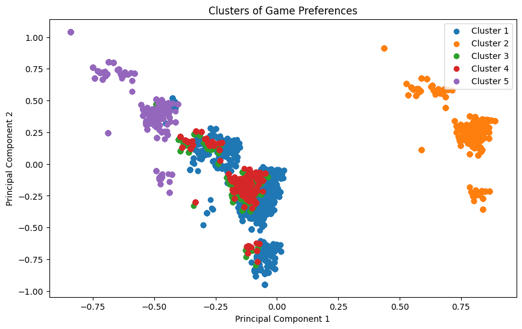

```python
# Apply PCA to reduce data to 2 dimensions
pca = PCA(n_components=2)
X_pca = pca.fit_transform(X_encoded.toarray())

# Plot the clusters
plt.figure(figsize=(10, 6))
for cluster in range(5):
    cluster_points = X_pca[cluster_labels == cluster]
    plt.scatter(cluster_points[:, 0], cluster_points[:, 1], label=f'Cluster {cluster+1}')

plt.title('Clusters of Game Preferences')
plt.xlabel('Principal Component 1')
plt.ylabel('Principal Component 2')
plt.legend()
plt.show()
```

Using characteristics like Publisher, Platform, and Genre, the given code uses K-means clustering on the dataset to find groups of similar game tastes. Users are then given game recommendations based on each of the identified clusters.

Games in Cluster 1 include "Dragon Ball Z: Battle of Z" (Fighting), "Petz: Dogz Family" (Simulation), and "Onimusha 2: Samurai's Destiny" (Adventure), demonstrating a wide variety of genres available on various platforms and publishers.

Action games dominate Cluster 2, with titles like "Hunter: The Reckoning Redeemer" and "SpongeBob SquarePants featuring Nicktoons: Glo..." indicating a strong platform preference for action games.

Games in the shooter genre, such as "Singularity" and "Delta Force: Black Hawk Down," are included in Cluster 3, which suggests a predilection for these kinds of games on platforms.

Racing games, such as "Drome Racers" and "The Dukes of Hazzard II: Daisy Dukes It Out," make up the majority of Cluster 4, which suggests a concentrated interest in racing games on many platforms.

Cluster 5 includes games with a sports theme, such as "Major League Baseball 2K9" and "Cabela's Dangerous Hunts 2," suggesting that people favor sports-themed games on platforms like Xbox and PlayStation.

Notice how the clusters are similar in size this could point to a number of underlying variables affecting the clustering outcomes. First of all, it implies that there can be some uniformity in the game sector, with consumers having comparable tastes across all niches. This may be explained by the fact that some game genres, platforms, or publishers are very popular with players, creating groups that are similar to one another. The low variety in the clustering features (publisher, genre, and platform) may also be a factor in the shape similarity of the clusters. When the majority of the games in the dataset have similar attributes, it can make it more difficult to form unique clusters with notably different properties. In addition, the sensitivity of the selected clustering algorithm and the availability and quality of the data used for clustering can have an additional impact on the clustering outcomes.

All things considered, the clustering algorithm is effective in identifying discrete gaming segments with different preferences, offering insights into the heterogeneous gaming market environment. To effectively cater to particular user interests, these clusters might inform marketing campaigns that are specifically targeted as well as game development efforts.

# **Insights and Conclusion**

In the end, our research into video game sales to and their ability to customize recommendations revealed complex dynamics in the gaming industry. We were able to understand the wide range of user preferences by examining clusters and where they were on the graph. In the visualization of our data, we can see that clusters 1, 3, and 4 showed overlap, indicating that users may have similar preferences for publishers, platforms, or genres. Additionally, cluster 5 was also more noticeable due to its higher placement, which could suggests that games in this area had more success abroad. But cluster 2 stood out as distinct from the others, emphasizing different customer preferences. These results serves to highlight the diverse range of user tastes and habits, along with the many niches in the gaming industry.

Given the dynamic nature of the gaming industry and our passion in this field, the effort we put into the research to assess video game sales and determine personalized recommendations is something we are quite passionate about and eager to do. The sheer number of game publishers, genres, and platforms over the decades have made it difficult to choose the best game. Our initiative in this project aimed to relieve this difficulty by utilizing insights derived from data. Using cluster algorithms and a thorough analysis of sales data up to 2016, our goal is to find patterns and trends that can be used to make recommendations that are specific to each customer's preferences.

Additionally, selecting the right clustering algorithm and settings can have a big impact on the results, producing clusters that differ in size and orientation according to different optimization factors. Some insights that we have gathered from training our algorithm model includes using more specific features in personalized recommendations, like user demographics or gameplay mechanics, experimenting with various clustering techniques, or carrying out additional research to identify the fundamental causes of user preferences and purchase behavior.

Our study is important not only for individual players but also for game developers and marketers. We help to improve user engagement and satisfaction by knowing what drives video game sales and anticipating customer preferences. Furthermore, our topic is in line with the trend of automatic recommendation systems, which are becoming more and more important in the digital age of entertainment and commerce. Our ultimate goal is to enhance the gaming experience for players, saving them money and time while fostering the expansion of the gaming sector.